# Language Translation

In this project, you’re going to take a peek into the realm of neural network machine translation. You’ll be training a sequence to sequence model on a dataset of English and French sentences that can translate new sentences from English to French.

## Get the Data

Since translating the whole language of English to French will take lots of time to train, we have provided you with a small portion of the English corpus.

```python
"""
DON'T MODIFY ANYTHING IN THIS CELL
"""
import helper
import problem_unittests as tests

source_path = 'data/small_vocab_en'
target_path = 'data/small_vocab_fr'
source_text = helper.load_data(source_path)
target_text = helper.load_data(target_path)
```

## Explore the Data

Play around with view_sentence_range to view different parts of the data.

```python
#index range of sentences to view, e.g. (0,10) means 0th to 9th for 10 total
view_sentence_range = (5, 10)

"""
DON'T MODIFY ANYTHING IN THIS CELL
"""
import numpy as np
''' TEMP
print('Dataset Stats')
word_list = source_text.split()
print(word_list[:50])
word_set = set(word_list)
print('Roughly the number of unique words (incl. punctuation): {}'.format(len(word_set)))

sentences = source_text.split('\n')
word_counts = [len(sentence.split()) for sentence in sentences]
print('Number of sentences: {}'.format(len(sentences)))
print('Average number of words in a sentence: {}'.format(np.average(word_counts)))

print()
print('English sentences {} to {}:'.format(*view_sentence_range))
print('\n'.join(source_text.split('\n')[view_sentence_range[0]:view_sentence_range[1]]))
print()
print('French sentences {} to {}:'.format(*view_sentence_range))
print('\n'.join(target_text.split('\n')[view_sentence_range[0]:view_sentence_range[1]]))
'''
```

[output not shown]

## Implement Preprocessing Function

### Text to Word Ids

As you did with other RNNs, you must turn the text into a number so the computer can understand it. In the function `text_to_ids()`, you'll turn `source_text` and `target_text` from words to ids. However, you need to add the `<EOS>` word id at the end of each sentence from `target_text`. This will help the neural network predict when the sentence should end.

You can get the `<EOS>` word id by doing:

```
target_vocab_to_int['<EOS>']
```

You can get other word ids using `source_vocab_to_int` and `target_vocab_to_int`.

```python
def text_to_ids(source_text, target_text, source_vocab_to_int, target_vocab_to_int):
    """
    Convert source and target text to proper word ids
    :param source_text: String that contains all the source text.
    :param target_text: String that contains all the target text.
    :param source_vocab_to_int: Dictionary to go from the source words to an id
    :param target_vocab_to_int: Dictionary to go from the target words to an id
    :return: A tuple of lists (source_id_text, target_id_text)
    """
    # TODO: Implement Function
    src_sentences = source_text.split('\n')
    source_id_text = []
    for sentence in src_sentences:
        source_id_text.append([source_vocab_to_int[word] for word in sentence.split()])
    targ_sentences = target_text.split('\n')
    target_id_text = []
    for sentence in targ_sentences:
        #Note that we only add the End-of-sentence flag at the end of the *target* sentences.
        sentence += ' <EOS>'
        target_id_text.append([target_vocab_to_int[word] for word in sentence.split()])

    #source_id_text is a list of sentences (lists) after conversion to integer IDs. Same for target_id_text.
    return source_id_text, target_id_text


"""
DON'T MODIFY ANYTHING IN THIS CELL THAT IS BELOW THIS LINE
"""
tests.test_text_to_ids(text_to_ids)
```

```
Tests Passed
```

### Preprocess all the data and save it

Running the code cell below will preprocess all the data and save it to file.

```python
"""
DON'T MODIFY ANYTHING IN THIS CELL
"""
import os.path as path
if path.isfile('preprocess.p') == False:
    print('preprocess_and_save_data')
    helper.preprocess_and_save_data(source_path, target_path, text_to_ids)
else:
    print("skip preprocess_and_save_data() because preprocessed file exists.")
```

```
skip preprocess_and_save_data() because preprocessed file exists.
```

# Check Point

This is your first checkpoint. If you ever decide to come back to this notebook or have to restart the notebook, you can start from here. The preprocessed data has been saved to disk.

```python
"""
DON'T MODIFY ANYTHING IN THIS CELL
"""
import numpy as np
import helper

(source_int_text, target_int_text), (source_vocab_to_int, target_vocab_to_int), _ = helper.load_preprocess()
```

### Check the Version of TensorFlow and Access to GPU

This will check to make sure you have the correct version of TensorFlow and access to a GPU

```python
"""
DON'T MODIFY ANYTHING IN THIS CELL
"""
from distutils.version import LooseVersion
import warnings
import tensorflow as tf

# Check TensorFlow Version
assert LooseVersion(tf.__version__) in [LooseVersion('1.0.0'), LooseVersion('1.0.1')], 'This project requires TensorFlow version 1.0  You are using {}'.format(tf.__version__)
print('TensorFlow Version: {}'.format(tf.__version__))

# Check for a GPU
if not tf.test.gpu_device_name():
    warnings.warn('No GPU found. Please use a GPU to train your neural network.')
else:
    print('Default GPU Device: {}'.format(tf.test.gpu_device_name()))
```

```
TensorFlow Version: 1.0.0
Default GPU Device: /gpu:0
```

## Build the Neural Network

You'll build the components necessary to build a Sequence-to-Sequence model by implementing the following functions below:

- `model_inputs`
- `process_decoding_input`
- `encoding_layer`
- `decoding_layer_train`
- `decoding_layer_infer`
- `decoding_layer`
- `seq2seq_model`

### Input

Implement the `model_inputs()` function to create TF Placeholders for the Neural Network. It should create the following placeholders:

- Input text placeholder named "input" using the TF Placeholder name parameter with rank 2.
- Targets placeholder with rank 2.
- Learning rate placeholder with rank 0.
- Keep probability placeholder named "keep_prob" using the TF Placeholder name parameter with rank 0.

Return the placeholders in the following the tuple (Input, Targets, Learing Rate, Keep Probability)

```python
def model_inputs():
    """
    Create TF Placeholders for input, targets, and learning rate.
    :return: Tuple (input, targets, learning rate, keep probability)
    """
    batch_size = None
    sequence_length = None
    # TODO: Implement Function
    input_data = tf.placeholder(tf.int32, shape=[batch_size, sequence_length], name="input")
    targets = tf.placeholder(tf.int32, shape=[batch_size, sequence_length], name="targets")
    lr = tf.placeholder(tf.float32, name="learning_rate")
    keep_prob = tf.placeholder(tf.float32, name="keep_prob")

    return input_data, targets, lr, keep_prob

"""
DON'T MODIFY ANYTHING IN THIS CELL THAT IS BELOW THIS LINE
"""
tests.test_model_inputs(model_inputs)
```

```
Tests Passed
```

### Process Decoding Input

Implement `process_decoding_input` using TensorFlow to remove the last word id from each batch in `target_data` and concat the GO ID to the beginning of each batch.

```python
def process_decoding_input(target_data, target_vocab_to_int, batch_size):
    """
    Preprocess target data for dencoding
    :param target_data: Target Placehoder
    :param target_vocab_to_int: Dictionary to go from the target words to an id
    :param batch_size: Batch Size
    :return: Preprocessed target data
    """
    # TODO: Implement Function
    ending = tf.strided_slice(target_data, [0, 0], [batch_size, -1], [1, 1])
    dec_input = tf.concat([tf.fill([batch_size, 1], target_vocab_to_int['<GO>']), ending], 1)

    return dec_input

"""
DON'T MODIFY ANYTHING IN THIS CELL THAT IS BELOW THIS LINE
"""
tests.test_process_decoding_input(process_decoding_input)
```

```
Tests Passed
```

### Encoding

Implement `encoding_layer()` to create a Encoder RNN layer using [`tf.nn.dynamic_rnn()`](https://www.tensorflow.org/api_docs/python/tf/nn/dynamic_rnn).

```python
def encoding_layer(rnn_inputs, rnn_size, num_layers, keep_prob):
    """
    Create encoding layer
    :param rnn_inputs: Inputs for the RNN
    :param rnn_size: RNN Size
    :param num_layers: Number of layers
    :param keep_prob: Dropout keep probability
    :return: RNN state
    """
    # TODO: Implement Function
    # Encoder
    # apply dropout with probability keep_prob to the basic LSTM cell.
    lstm_cell = tf.contrib.rnn.DropoutWrapper(tf.contrib.rnn.BasicLSTMCell(rnn_size), output_keep_prob=keep_prob)
    # Stack up this cell in layers of depth num_layers.
    enc_cell = tf.contrib.rnn.MultiRNNCell([lstm_cell] * num_layers)
    _, enc_state = tf.nn.dynamic_rnn(enc_cell, rnn_inputs, dtype=tf.float32)
    return enc_state

"""
DON'T MODIFY ANYTHING IN THIS CELL THAT IS BELOW THIS LINE
"""
tests.test_encoding_layer(encoding_layer)
```

```
Tests Passed
```

### Decoding - Training

Create training logits using [`tf.contrib.seq2seq.simple_decoder_fn_train()`](https://www.tensorflow.org/versions/r1.0/api_docs/python/tf/contrib/seq2seq/simple_decoder_fn_train) and [`tf.contrib.seq2seq.dynamic_rnn_decoder()`](https://www.tensorflow.org/versions/r1.0/api_docs/python/tf/contrib/seq2seq/dynamic_rnn_decoder). Apply the `output_fn` to the [`tf.contrib.seq2seq.dynamic_rnn_decoder()`](https://www.tensorflow.org/versions/r1.0/api_docs/python/tf/contrib/seq2seq/dynamic_rnn_decoder) outputs.

```python
def decoding_layer_train(encoder_state, dec_cell, dec_embed_input, sequence_length, decoding_scope,
                         output_fn, keep_prob):
    """
    Create a decoding layer for training
    :param encoder_state: Encoder State
    :param dec_cell: Decoder RNN Cell
    :param dec_embed_input: Decoder embedded input
    :param sequence_length: Sequence Length
    :param decoding_scope: TensorFlow Variable Scope for decoding
    :param output_fn: Function to apply the output layer
    :param keep_prob: Dropout keep probability
    :return: Train Logits
    """
    # TODO: Implement Function
    # #### Decoder During Training
    # - Build the training decoder using [`tf.contrib.seq2seq.simple_decoder_fn_train`](https://www.tensorflow.org/api_docs/python/tf/contrib/seq2seq/simple_decoder_fn_train) and [`tf.contrib.seq2seq.dynamic_rnn_decoder`](https://www.tensorflow.org/api_docs/python/tf/contrib/seq2seq/dynamic_rnn_decoder).
    # - Apply the output layer to the output of the training decoder

    # Training Decoder
    train_decoder_fn = tf.contrib.seq2seq.simple_decoder_fn_train(encoder_state)
    #apply droput to decoder cell
    drop_cell = tf.contrib.rnn.DropoutWrapper(dec_cell, keep_prob)

    train_pred, _, _ = tf.contrib.seq2seq.dynamic_rnn_decoder(
        drop_cell, train_decoder_fn, dec_embed_input, sequence_length, scope=decoding_scope)

    # Apply output function
    train_logits = output_fn(train_pred)
    return train_logits


"""
DON'T MODIFY ANYTHING IN THIS CELL THAT IS BELOW THIS LINE
"""
tests.test_decoding_layer_train(decoding_layer_train)
```

```
Tests Passed
```

### Decoding - Inference

Create inference logits using [`tf.contrib.seq2seq.simple_decoder_fn_inference()`](https://www.tensorflow.org/versions/r1.0/api_docs/python/tf/contrib/seq2seq/simple_decoder_fn_inference) and [`tf.contrib.seq2seq.dynamic_rnn_decoder()`](https://www.tensorflow.org/versions/r1.0/api_docs/python/tf/contrib/seq2seq/dynamic_rnn_decoder).

```python
def decoding_layer_infer(encoder_state, dec_cell, dec_embeddings, start_of_sequence_id, end_of_sequence_id,
                         maximum_length, vocab_size, decoding_scope, output_fn, keep_prob):
    """
    Create a decoding layer for inference
    :param encoder_state: Encoder state
    :param dec_cell: Decoder RNN Cell
    :param dec_embeddings: Decoder embeddings
    :param start_of_sequence_id: GO ID
    :param end_of_sequence_id: EOS Id
    :param maximum_length: The maximum allowed time steps to decode
    :param vocab_size: Size of vocabulary
    :param decoding_scope: TensorFlow Variable Scope for decoding
    :param output_fn: Function to apply the output layer
    :param keep_prob: Dropout keep probability
    :return: Inference Logits
    """
    # TODO: Implement Function
    # #### Decoder During Inference
    # - Reuse the weights the biases from the training decoder using [`tf.variable_scope("decoding", reuse=True)`](https://www.tensorflow.org/api_docs/python/tf/variable_scope)
    # - Build the inference decoder using [`tf.contrib.seq2seq.simple_decoder_fn_inference`](https://www.tensorflow.org/api_docs/python/tf/contrib/seq2seq/simple_decoder_fn_inference) and [`tf.contrib.seq2seq.dynamic_rnn_decoder`](https://www.tensorflow.org/api_docs/python/tf/contrib/seq2seq/dynamic_rnn_decoder).
    #  - The output function is applied to the output in this step
    infer_decoder_fn = tf.contrib.seq2seq.simple_decoder_fn_inference(
        output_fn, encoder_state, dec_embeddings, start_of_sequence_id, end_of_sequence_id,
        maximum_length, vocab_size)
    #apply droput to decoder cell
    drop_cell = tf.contrib.rnn.DropoutWrapper(dec_cell, keep_prob)
    inference_logits, _, _ = tf.contrib.seq2seq.dynamic_rnn_decoder(drop_cell, infer_decoder_fn, scope=decoding_scope)

    return inference_logits


"""
DON'T MODIFY ANYTHING IN THIS CELL THAT IS BELOW THIS LINE
"""
tests.test_decoding_layer_infer(decoding_layer_infer)
```

```
Tests Passed
```

### Build the Decoding Layer

Implement `decoding_layer()` to create a Decoder RNN layer.

- Create RNN cell for decoding using `rnn_size` and `num_layers`.
- Create the output fuction using [`lambda`](https://docs.python.org/3/tutorial/controlflow.html#lambda-expressions) to transform it's input, logits, to class logits.
- Use the your `decoding_layer_train(encoder_state, dec_cell, dec_embed_input, sequence_length, decoding_scope, output_fn, keep_prob)` function to get the training logits.
- Use your `decoding_layer_infer(encoder_state, dec_cell, dec_embeddings, start_of_sequence_id, end_of_sequence_id, maximum_length, vocab_size, decoding_scope, output_fn, keep_prob)` function to get the inference logits.

Note: You'll need to use [tf.variable_scope](https://www.tensorflow.org/api_docs/python/tf/variable_scope) to share variables between training and inference.

```python
def decoding_layer(dec_embed_input, dec_embeddings, encoder_state, vocab_size, sequence_length, rnn_size,
                   num_layers, target_vocab_to_int, keep_prob):
    """
    Create decoding layer
    :param dec_embed_input: Decoder embedded input
    :param dec_embeddings: Decoder embeddings
    :param encoder_state: The encoded state
    :param vocab_size: Size of vocabulary (target)
    :param sequence_length: Sequence Length
    :param rnn_size: RNN Size
    :param num_layers: Number of layers
    :param target_vocab_to_int: Dictionary to go from the target words to an id
    :param keep_prob: Dropout keep probability
    :return: Tuple of (Training Logits, Inference Logits)
    """
    # TODO: Implement Function

    # Decoder RNNs
    dec_cell = tf.contrib.rnn.BasicLSTMCell(rnn_size)
    drop_cell = tf.contrib.rnn.DropoutWrapper(dec_cell, keep_prob)
    train_cell = tf.contrib.rnn.MultiRNNCell([drop_cell] * num_layers)
    with tf.variable_scope("decoding") as decoding_scope:
        # Output Layer
        output_fn = lambda x: tf.contrib.layers.fully_connected(x, vocab_size, None, scope=decoding_scope)
        # Training Decoder
        train_logits = decoding_layer_train(encoder_state, train_cell, dec_embed_input, sequence_length, decoding_scope,
            output_fn, keep_prob)
    #reuse=True means we reuse the weights and biases from the training for the inference.
    with tf.variable_scope("decoding", reuse=True) as decoding_scope:
        # Inference Decoder
        inference_logits = decoding_layer_infer(encoder_state, train_cell, dec_embeddings, target_vocab_to_int['<GO>'],
            target_vocab_to_int['<EOS>'], sequence_length-1, vocab_size, decoding_scope, output_fn, keep_prob)

    return train_logits, inference_logits


"""
DON'T MODIFY ANYTHING IN THIS CELL THAT IS BELOW THIS LINE
"""
tests.test_decoding_layer(decoding_layer)
```

```
Tests Passed
```

### Build the Neural Network

Apply the functions you implemented above to:

- Apply embedding to the input data for the encoder.
- Encode the input using your `encoding_layer(rnn_inputs, rnn_size, num_layers, keep_prob)`.
- Process target data using your `process_decoding_input(target_data, target_vocab_to_int, batch_size)` function.
- Apply embedding to the target data for the decoder.
- Decode the encoded input using your `decoding_layer(dec_embed_input, dec_embeddings, encoder_state, vocab_size, sequence_length, rnn_size, num_layers, target_vocab_to_int, keep_prob)`.

```python
def seq2seq_model(input_data, target_data, keep_prob, batch_size, sequence_length, source_vocab_size, target_vocab_size,
                  enc_embedding_size, dec_embedding_size, rnn_size, num_layers, target_vocab_to_int):
    """
    Build the Sequence-to-Sequence part of the neural network
    :param input_data: Input placeholder
    :param target_data: Target placeholder
    :param keep_prob: Dropout keep probability placeholder
    :param batch_size: Batch Size
    :param sequence_length: Sequence Length
    :param source_vocab_size: Source vocabulary size
    :param target_vocab_size: Target vocabulary size
    :param enc_embedding_size: Decoder embedding size
    :param dec_embedding_size: Encoder embedding size
    :param rnn_size: RNN Size
    :param num_layers: Number of layers
    :param target_vocab_to_int: Dictionary to go from the target words to an id
    :return: Tuple of (Training Logits, Inference Logits)
    """
    # TODO: Implement Function
    # ### Encoding
    # - Embed the input data using [`tf.contrib.layers.embed_sequence`](https://www.tensorflow.org/api_docs/python/tf/contrib/layers/embed_sequence)
    # - Pass the embedded input into a stack of RNNs.  Save the RNN state and ignore the output.

    # Encoder embedding
    enc_embed_input = tf.contrib.layers.embed_sequence(input_data, source_vocab_size, enc_embedding_size)
    # Encoder
    enc_state = encoding_layer(enc_embed_input, rnn_size, num_layers, keep_prob)
    # Process the input we'll feed to the decoder
    dec_input = process_decoding_input(target_data, target_vocab_to_int, batch_size)
    # Decoder Embedding
    dec_embeddings = tf.Variable(tf.random_uniform([target_vocab_size, dec_embedding_size]))
    dec_embed_input = tf.nn.embedding_lookup(dec_embeddings, dec_input)
    # Decoder RNN layer
    train_logits, inference_logits = decoding_layer(dec_embed_input, dec_embeddings, enc_state, target_vocab_size,
                   sequence_length, rnn_size, num_layers, target_vocab_to_int, keep_prob)

    return train_logits, inference_logits


"""
DON'T MODIFY ANYTHING IN THIS CELL THAT IS BELOW THIS LINE
"""
tests.test_seq2seq_model(seq2seq_model)
```

```
Tests Passed
```

## Neural Network Training

### Hyperparameters

Tune the following parameters:

- Set `epochs` to the number of epochs.
- Set `batch_size` to the batch size.
- Set `rnn_size` to the size of the RNNs.
- Set `num_layers` to the number of layers.
- Set `encoding_embedding_size` to the size of the embedding for the encoder.
- Set `decoding_embedding_size` to the size of the embedding for the decoder.
- Set `learning_rate` to the learning rate.
- Set `keep_probability` to the Dropout keep probability

```python
# Number of Epochs
epochs = 4
# Batch Size
batch_size = 128 #BEST 128. 1024 was worse
# RNN Size
rnn_size = 512 #BEST 512. 128 was worse
# Number of Layers
num_layers = 4 #BEST 4
# Embedding Size
encoding_embedding_size = 25 #BEST 25. 100 was worse
decoding_embedding_size = 25 #same
# Learning Rate
learning_rate = 0.001 #BEST 0.001.  0.01 was worse
# Dropout Keep Probability
keep_probability = 0.5 #BEST 0.75. 0.5 may be worse
```

### Build the Graph

Build the graph using the neural network you implemented.

```python
"""
DON'T MODIFY ANYTHING IN THIS CELL
"""
save_path = 'checkpoints/dev'
(source_int_text, target_int_text), (source_vocab_to_int, target_vocab_to_int), _ = helper.load_preprocess()
max_source_sentence_length = max([len(sentence) for sentence in source_int_text])

train_graph = tf.Graph()
with train_graph.as_default():
    input_data, targets, lr, keep_prob = model_inputs()
    sequence_length = tf.placeholder_with_default(max_source_sentence_length, None, name='sequence_length')
    input_shape = tf.shape(input_data)

    train_logits, inference_logits = seq2seq_model(
        tf.reverse(input_data, [-1]), targets, keep_prob, batch_size, sequence_length, len(source_vocab_to_int), len(target_vocab_to_int),
        encoding_embedding_size, decoding_embedding_size, rnn_size, num_layers, target_vocab_to_int)

    tf.identity(inference_logits, 'logits')
    with tf.name_scope("optimization"):
        # Loss function
        cost = tf.contrib.seq2seq.sequence_loss(
            train_logits,
            targets,
            tf.ones([input_shape[0], sequence_length]))

        # Optimizer
        optimizer = tf.train.AdamOptimizer(lr)

        # Gradient Clipping
        gradients = optimizer.compute_gradients(cost)
        capped_gradients = [(tf.clip_by_value(grad, -1., 1.), var) for grad, var in gradients if grad is not None]
        train_op = optimizer.apply_gradients(capped_gradients)
```

### Train

Train the neural network on the preprocessed data. If you have a hard time getting a good loss, check the forms to see if anyone is having the same problem.

```python
"""
DON'T MODIFY ANYTHING IN THIS CELL
"""
import time

def get_accuracy(target, logits):
    """
    Calculate accuracy
    """
    max_seq = max(target.shape[1], logits.shape[1])
    if max_seq - target.shape[1]:
        target = np.pad(
            target,
            [(0,0),(0,max_seq - target.shape[1])],
            'constant')
    if max_seq - logits.shape[1]:
        logits = np.pad(
            logits,
            [(0,0),(0,max_seq - logits.shape[1]), (0,0)],
            'constant')

    return np.mean(np.equal(target, np.argmax(logits, 2)))

train_source = source_int_text[batch_size:]
train_target = target_int_text[batch_size:]

valid_source = helper.pad_sentence_batch(source_int_text[:batch_size])
valid_target = helper.pad_sentence_batch(target_int_text[:batch_size])

#lists that will be used to plot the training metrics
train_acc_list = []
valid_acc_list = []
loss_list = []
with tf.Session(graph=train_graph) as sess:
    sess.run(tf.global_variables_initializer())

    for epoch_i in range(epochs):
        for batch_i, (source_batch, target_batch) in enumerate(
                helper.batch_data(train_source, train_target, batch_size)):
            start_time = time.time()

            _, loss = sess.run(
                [train_op, cost],
                {input_data: source_batch,
                 targets: target_batch,
                 lr: learning_rate,
                 sequence_length: target_batch.shape[1],
                 keep_prob: keep_probability})

            batch_train_logits = sess.run(
                inference_logits,
                {input_data: source_batch, keep_prob: 1.0})
            batch_valid_logits = sess.run(
                inference_logits,
                {input_data: valid_source, keep_prob: 1.0})

            train_acc = get_accuracy(target_batch, batch_train_logits)
            valid_acc = get_accuracy(np.array(valid_target), batch_valid_logits)
            end_time = time.time()
            #Update lists used for plotting the training metrics
            train_acc_list.append(train_acc)
            valid_acc_list.append(valid_acc)
            loss_list.append(loss)

            print('Epoch {:>3} Batch {:>4}/{} - Train Accuracy: {:>6.3f}, Validation Accuracy: {:>6.3f}, Loss: {:>6.3f}'
                  .format(epoch_i, batch_i, len(source_int_text) // batch_size, train_acc, valid_acc, loss))

    # Save Model
    saver = tf.train.Saver()
    saver.save(sess, save_path)
    print('Model Trained and Saved')
```

```
Epoch   0 Batch    0/1077 - Train Accuracy:  0.294, Validation Accuracy:  0.305, Loss:  5.885
Epoch   0 Batch    1/1077 - Train Accuracy:  0.221, Validation Accuracy:  0.305, Loss:  5.699
Epoch   0 Batch    2/1077 - Train Accuracy:  0.206, Validation Accuracy:  0.305, Loss:  4.772
Epoch   0 Batch    3/1077 - Train Accuracy:  0.270, Validation Accuracy:  0.335, Loss:  5.175
Epoch   0 Batch    4/1077 - Train Accuracy:  0.263, Validation Accuracy:  0.337, Loss:  4.299
Epoch   0 Batch    5/1077 - Train Accuracy:  0.296, Validation Accuracy:  0.338, Loss:  4.333
Epoch   0 Batch    6/1077 - Train Accuracy:  0.280, Validation Accuracy:  0.338, Loss:  4.218
Epoch   0 Batch    7/1077 - Train Accuracy:  0.262, Validation Accuracy:  0.337, Loss:  3.951
Epoch   0 Batch    8/1077 - Train Accuracy:  0.269, Validation Accuracy:  0.337, Loss:  3.724
Epoch   0 Batch    9/1077 - Train Accuracy:  0.307, Validation Accuracy:  0.366, Loss:  3.564
Epoch   0 Batch   10/1077 - Train Accuracy:  0.260, Validation Accuracy:  0.365, Loss:  3.658
Epoch   0 Batch   11/1077 - Train Accuracy:  0.326, Validation Accuracy:  0.366, Loss:  3.346
Epoch   0 Batch   12/1077 - Train Accuracy:  0.302, Validation Accuracy:  0.365, Loss:  3.416
Epoch   0 Batch   13/1077 - Train Accuracy:  0.340, Validation Accuracy:  0.362, Loss:  3.200
Epoch   0 Batch   14/1077 - Train Accuracy:  0.321, Validation Accuracy:  0.362, Loss:  3.148
Epoch   0 Batch   15/1077 - Train Accuracy:  0.303, Validation Accuracy:  0.367, Loss:  3.263
Epoch   0 Batch   16/1077 - Train Accuracy:  0.320, Validation Accuracy:  0.365, Loss:  3.211
Epoch   0 Batch   17/1077 - Train Accuracy:  0.327, Validation Accuracy:  0.372, Loss:  3.153
Epoch   0 Batch   18/1077 - Train Accuracy:  0.305, Validation Accuracy:  0.373, Loss:  3.180
Epoch   0 Batch   19/1077 - Train Accuracy:  0.343, Validation Accuracy:  0.385, Loss:  3.061
Epoch   0 Batch   20/1077 - Train Accuracy:  0.330, Validation Accuracy:  0.391, Loss:  3.072
Epoch   0 Batch   21/1077 - Train Accuracy:  0.323, Validation Accuracy:  0.393, Loss:  3.119
Epoch   0 Batch   22/1077 - Train Accuracy:  0.342, Validation Accuracy:  0.402, Loss:  3.078
Epoch   0 Batch   23/1077 - Train Accuracy:  0.335, Validation Accuracy:  0.400, Loss:  3.079
Epoch   0 Batch   24/1077 - Train Accuracy:  0.353, Validation Accuracy:  0.403, Loss:  2.969
Epoch   0 Batch   25/1077 - Train Accuracy:  0.321, Validation Accuracy:  0.379, Loss:  3.048
Epoch   0 Batch   26/1077 - Train Accuracy:  0.330, Validation Accuracy:  0.401, Loss:  3.099
Epoch   0 Batch   27/1077 - Train Accuracy:  0.375, Validation Accuracy:  0.401, Loss:  2.785
Epoch   0 Batch   28/1077 - Train Accuracy:  0.357, Validation Accuracy:  0.407, Loss:  2.905
Epoch   0 Batch   29/1077 - Train Accuracy:  0.356, Validation Accuracy:  0.408, Loss:  2.848
Epoch   0 Batch   30/1077 - Train Accuracy:  0.358, Validation Accuracy:  0.412, Loss:  2.830
Epoch   0 Batch   31/1077 - Train Accuracy:  0.356, Validation Accuracy:  0.417, Loss:  2.859
Epoch   0 Batch   32/1077 - Train Accuracy:  0.424, Validation Accuracy:  0.438, Loss:  2.652
Epoch   0 Batch   33/1077 - Train Accuracy:  0.419, Validation Accuracy:  0.433, Loss:  2.623
Epoch   0 Batch   34/1077 - Train Accuracy:  0.389, Validation Accuracy:  0.440, Loss:  2.726
Epoch   0 Batch   35/1077 - Train Accuracy:  0.378, Validation Accuracy:  0.431, Loss:  2.693
Epoch   0 Batch   36/1077 - Train Accuracy:  0.397, Validation Accuracy:  0.447, Loss:  2.673
Epoch   0 Batch   37/1077 - Train Accuracy:  0.398, Validation Accuracy:  0.448, Loss:  2.662
Epoch   0 Batch   38/1077 - Train Accuracy:  0.362, Validation Accuracy:  0.450, Loss:  2.852
Epoch   0 Batch   39/1077 - Train Accuracy:  0.391, Validation Accuracy:  0.451, Loss:  2.676
```

[output cut: 4250 more lines]

```
Epoch   3 Batch 1062/1077 - Train Accuracy:  0.902, Validation Accuracy:  0.912, Loss:  0.068
Epoch   3 Batch 1063/1077 - Train Accuracy:  0.933, Validation Accuracy:  0.907, Loss:  0.062
Epoch   3 Batch 1064/1077 - Train Accuracy:  0.954, Validation Accuracy:  0.916, Loss:  0.054
Epoch   3 Batch 1065/1077 - Train Accuracy:  0.924, Validation Accuracy:  0.920, Loss:  0.051
Epoch   3 Batch 1066/1077 - Train Accuracy:  0.916, Validation Accuracy:  0.920, Loss:  0.060
Epoch   3 Batch 1067/1077 - Train Accuracy:  0.930, Validation Accuracy:  0.909, Loss:  0.061
Epoch   3 Batch 1068/1077 - Train Accuracy:  0.943, Validation Accuracy:  0.909, Loss:  0.054
Epoch   3 Batch 1069/1077 - Train Accuracy:  0.930, Validation Accuracy:  0.916, Loss:  0.047
Epoch   3 Batch 1070/1077 - Train Accuracy:  0.914, Validation Accuracy:  0.920, Loss:  0.055
Epoch   3 Batch 1071/1077 - Train Accuracy:  0.915, Validation Accuracy:  0.926, Loss:  0.052
Epoch   3 Batch 1072/1077 - Train Accuracy:  0.943, Validation Accuracy:  0.921, Loss:  0.059
Epoch   3 Batch 1073/1077 - Train Accuracy:  0.929, Validation Accuracy:  0.917, Loss:  0.067
Epoch   3 Batch 1074/1077 - Train Accuracy:  0.945, Validation Accuracy:  0.913, Loss:  0.072
Epoch   3 Batch 1075/1077 - Train Accuracy:  0.907, Validation Accuracy:  0.915, Loss:  0.080
Model Trained and Saved
```

### Save Parameters

Save the `batch_size` and `save_path` parameters for inference.

```python
"""
DON'T MODIFY ANYTHING IN THIS CELL
"""
# Save parameters for checkpoint
helper.save_params(save_path)
```

# Checkpoint

```python
"""
DON'T MODIFY ANYTHING IN THIS CELL
"""
import tensorflow as tf
import numpy as np
import helper
import problem_unittests as tests

_, (source_vocab_to_int, target_vocab_to_int), (source_int_to_vocab, target_int_to_vocab) = helper.load_preprocess()
load_path = helper.load_params()
```

## Sentence to Sequence

To feed a sentence into the model for translation, you first need to preprocess it. Implement the function `sentence_to_seq()` to preprocess new sentences.

- Convert the sentence to lowercase
- Convert words into ids using `vocab_to_int`
  - Convert words not in the vocabulary, to the `<UNK>` word id.

```python
def sentence_to_seq(sentence, vocab_to_int):
    """
    Convert a sentence to a sequence of ids
    :param sentence: String
    :param vocab_to_int: Dictionary to go from the words to an id
    :return: List of word ids
    """
    # TODO: Implement Function
    out_list = sentence.lower().split()
    #ensure that any words not in vocabulary are replaced by '<UNK>' word (which exists in our vocab).
    out_list = [word if word in vocab_to_int.keys() else '<UNK>' for word in out_list ]
    #convert all the words to integer IDs.
    out_list = [vocab_to_int[word] for word in out_list ]

    return out_list


"""
DON'T MODIFY ANYTHING IN THIS CELL THAT IS BELOW THIS LINE
"""
tests.test_sentence_to_seq(sentence_to_seq)
```

```
Tests Passed
```

## Translate

This will translate `translate_sentence` from English to French.

```python
translate_sentence = 'he saw a old yellow truck .'

"""
DON'T MODIFY ANYTHING IN THIS CELL
"""
translate_sentence = sentence_to_seq(translate_sentence, source_vocab_to_int)

loaded_graph = tf.Graph()
with tf.Session(graph=loaded_graph) as sess:
    # Load saved model
    loader = tf.train.import_meta_graph(load_path + '.meta')
    loader.restore(sess, load_path)

    input_data = loaded_graph.get_tensor_by_name('input:0')
    logits = loaded_graph.get_tensor_by_name('logits:0')
    keep_prob = loaded_graph.get_tensor_by_name('keep_prob:0')

    translate_logits = sess.run(logits, {input_data: [translate_sentence], keep_prob: 1.0})[0]

print('Input')
print('  Word Ids:      {}'.format([i for i in translate_sentence]))
print('  English Words: {}'.format([source_int_to_vocab[i] for i in translate_sentence]))

print('\nPrediction')
print('  Word Ids:      {}'.format([i for i in np.argmax(translate_logits, 1)]))
print('  French Words: {}'.format([target_int_to_vocab[i] for i in np.argmax(translate_logits, 1)]))

#show the sentence excluding the special flags (e.g. <PAD> or <UNK>)
sent = ' '.join([target_int_to_vocab[i] for i in np.argmax(translate_logits, 1) if i>3])
print('  French Sentence: {}'.format(sent) )
```

```
Input
  Word Ids:      [84, 152, 119, 177, 213, 163, 39]
  English Words: ['he', 'saw', 'a', 'old', 'yellow', 'truck', '.']

Prediction
  Word Ids:      [335, 31, 155, 19, 197, 81, 278, 1]
  French Words: ['il', 'a', 'vu', 'une', 'voiture', 'rouge', '.', '<EOS>']
  French Sentence: il a vu une voiture rouge .
```

## Plotting the Training

This will plot the training & accuracy, and on a separate graph the loss vs batch steps (all epochs).

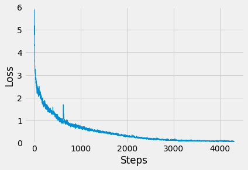

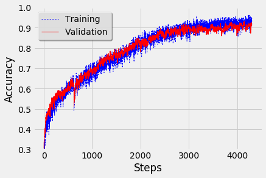

```
  Best Validation Accuracy was 0.93 at step 4148 with loss 0.06
```

```python
import matplotlib.pyplot as plt
# plot loss
with plt.style.context('fivethirtyeight'):
    plt.plot(loss_list, linewidth = 1)
    plt.xlabel('Steps')
    plt.ylabel('Loss')
    plt.ylim((0, 6))

plt.show()

t = np.arange(0, len(train_acc_list))
# plot train and validation accuracy
with plt.style.context('fivethirtyeight'):
    fig, ax = plt.subplots()
    ax.plot(t, train_acc_list, 'b:', label='Training', linewidth = 1)
    ax.plot(t, valid_acc_list, 'r', label='Validation', linewidth = 1)
    plt.xlabel('Steps')
    plt.ylabel('Accuracy')
    plt.ylim((0.3, 1))
    legend = ax.legend(loc='upper left', shadow=True)

plt.show()
i = np.argmax(np.array(valid_acc_list))
print('\n  Best Validation Accuracy was {:.2f} at step {} with loss {:.2f}'.format(valid_acc_list[i],i,loss_list[i]) )
```

## Imperfect Translation

You might notice that some sentences translate better than others. Since the dataset you're using only has a vocabulary of 227 English words of the thousands that you use, you're only going to see good results using these words. For this project, you don't need a perfect translation. However, if you want to create a better translation model, you'll need better data.

You can train on the [WMT10 French-English corpus](http://www.statmt.org/wmt10/training-giga-fren.tar). This dataset has more vocabulary and richer in topics discussed. However, this will take you days to train, so make sure you've a GPU and the neural network is performing well on dataset we provided. Just make sure you play with the WMT10 corpus after you've submitted this project.

## Submitting This Project

When submitting this project, make sure to run all the cells before saving the notebook. Save the notebook file as "dlnd_language_translation.ipynb" and save it as a HTML file under "File" -> "Download as". Include the "helper.py" and "problem_unittests.py" files in your submission.